## Project: Problem Statement - Personal Loan Campaign Modelling

# Thera Bank Personal Loan Campaign

# Data Description:

The dataset contains data on 5000 customers. The data include customer demographic information (age, income, etc.), the customer's relationship with the bank (mortgage, securities account, etc.), and the customer response to the last personal loan campaign (Personal Loan). Among these 5000 customers, only 480 (= 9.6%) accepted the personal loan that was offered to them in the earlier campaign.

# Domain:

Banking

# Context:

This case is about a bank (Thera Bank) whose management wants to explore ways of converting its liability customers to personal loan customers (while retaining them as depositors). A campaign that the bank ran last year for liability customers showed a healthy conversion rate of over 9% success. This has encouraged the retail marketing department to devise campaigns with better target marketing to increase the success ratio with a minimal budget.

# Attribute Information:

ID: Customer ID Age: Customer's age in completed years Experience: #years of professional experience Income: Annual income of the customer (000) ZIP Code: Home Address ZIP Family: Family size of the customer CCAvg: Avg. spending on credit cards per month (000) Education: Education Level. 1: Undergrad; 2: Graduate; 3: Advanced/Professional Mortgage: Value of house mortgage if any. (000) Personal Loan: Did this customer accept the personal loan offered in the last campaign? Securities Account: Does the customer have a securities account with the bank? CD Account: Does the customer have a certificate of deposit (CD) account with the bank? Online: Does the customer use internet banking facilities? Credit card: Does the customer use a credit card issued by the bank?

# Learning Outcomes:

Exploratory Data Analysis Preparing the data to train a model Training and making predictions using a classification model Model evaluation

# Objective:

The classification goal is to predict the likelihood of a liability customer buying personal loans.

# Steps and tasks:

Import the datasets and libraries, check datatype, statistical summary, shape, null values or incorrect imputation. (5 marks) EDA: Study the data distribution in each attribute and target variable, share your findings (20 marks) Number of unique in each column? Number of people with zero mortgage? Number of people with zero credit card spending per month? Value counts of all categorical columns. Univariate and Bivariate Get data model ready Split the data into training and test set in the ratio of 70:30 respectively (5 marks) Use the Logistic Regression model to predict whether the customer will take a personal loan or not. Print all the metrics related to evaluating the model performance (accuracy, recall, precision, f1score, and roc_auc_score). Draw a heatmap to display confusion matrix (15 marks) Find out coefficients of all the attributes and show the output in a data frame with column names? For test data show all the rows where the predicted class is not equal to the observed class. (10 marks) Give conclusion related to the Business understanding of your model? (5 marks)

```python
import warnings
warnings.filterwarnings('ignore')
```

```python
import pandas as pd
import numpy as np
from scipy import stats
from sklearn.linear_model import LogisticRegression

# importing ploting libraries
import matplotlib.pyplot as plt
# To enable plotting graphs in Jupyter notebook
%matplotlib inline

#importing seaborn for statistical plots
import seaborn as sns

#Let us break the X and y dataframes into training set and test set. For this we will use
#Sklearn package's data splitting function which is based on random function

from sklearn.model_selection import train_test_split
import statsmodels.api as sm
from sklearn.linear_model import LinearRegression
from sklearn.metrics import mean_squared_error



# calculate accuracy measures and confusion matrix
from sklearn import metrics

# Remove scientific notations and display numbers with 2 decimal points instead
pd.options.display.float_format = '{:,.2f}'.format
```

```python
#Load data
bank_df = pd.read_csv('Bank_Personal_Loan_Modelling.csv')
```

```python
#Inspect the dataframe
#Print the head
bank_df.head()
```

|  | ID | Age | Experience | Income | ZIP Code | Family | CCAvg | Education | Mortgage | Personal Loan | Securities Account | CD Account | Online | CreditCard |
| --- | --- | --- | --- | --- | --- | --- | --- | --- | --- | --- | --- | --- | --- | --- |
| 0 | 1 | 25 | 1 | 49 | 91107 | 4 | 1.60 | 1 | 0 | 0 | 1 | 0 | 0 | 0 |
| 1 | 2 | 45 | 19 | 34 | 90089 | 3 | 1.50 | 1 | 0 | 0 | 1 | 0 | 0 | 0 |
| 2 | 3 | 39 | 15 | 11 | 94720 | 1 | 1.00 | 1 | 0 | 0 | 0 | 0 | 0 | 0 |
| 3 | 4 | 35 | 9 | 100 | 94112 | 1 | 2.70 | 2 | 0 | 0 | 0 | 0 | 0 | 0 |
| 4 | 5 | 35 | 8 | 45 | 91330 | 4 | 1.00 | 2 | 0 | 0 | 0 | 0 | 0 | 1 |

```python
#Check How many records we have
bank_df.shape
```

```
(5000, 14)
```

```python
# Inspect the Column Types
bank_df.info()
```

```
<class 'pandas.core.frame.DataFrame'>
RangeIndex: 5000 entries, 0 to 4999
Data columns (total 14 columns):
 #   Column              Non-Null Count  Dtype
---  ------              --------------  -----
 0   ID                  5000 non-null   int64
 1   Age                 5000 non-null   int64
 2   Experience          5000 non-null   int64
 3   Income              5000 non-null   int64
 4   ZIP Code            5000 non-null   int64
 5   Family              5000 non-null   int64
 6   CCAvg               5000 non-null   float64
 7   Education           5000 non-null   int64
 8   Mortgage            5000 non-null   int64
 9   Personal Loan       5000 non-null   int64
 10  Securities Account  5000 non-null   int64
 11  CD Account          5000 non-null   int64
 12  Online              5000 non-null   int64
 13  CreditCard          5000 non-null   int64
dtypes: float64(1), int64(13)
memory usage: 547.0 KB
```

```python
# Get Statistical Details of the data
bank_df.describe()
```

|  | ID | Age | Experience | Income | ZIP Code | Family | CCAvg | Education | Mortgage | Personal Loan | Securities Account | CD Account | Online | CreditCard |
| --- | --- | --- | --- | --- | --- | --- | --- | --- | --- | --- | --- | --- | --- | --- |
| count | 5,000.00 | 5,000.00 | 5,000.00 | 5,000.00 | 5,000.00 | 5,000.00 | 5,000.00 | 5,000.00 | 5,000.00 | 5,000.00 | 5,000.00 | 5,000.00 | 5,000.00 | 5,000.00 |
| mean | 2,500.50 | 45.34 | 20.10 | 73.77 | 93,152.50 | 2.40 | 1.94 | 1.88 | 56.50 | 0.10 | 0.10 | 0.06 | 0.60 | 0.29 |
| std | 1,443.52 | 11.46 | 11.47 | 46.03 | 2,121.85 | 1.15 | 1.75 | 0.84 | 101.71 | 0.29 | 0.31 | 0.24 | 0.49 | 0.46 |
| min | 1.00 | 23.00 | -3.00 | 8.00 | 9,307.00 | 1.00 | 0.00 | 1.00 | 0.00 | 0.00 | 0.00 | 0.00 | 0.00 | 0.00 |
| 25% | 1,250.75 | 35.00 | 10.00 | 39.00 | 91,911.00 | 1.00 | 0.70 | 1.00 | 0.00 | 0.00 | 0.00 | 0.00 | 0.00 | 0.00 |
| 50% | 2,500.50 | 45.00 | 20.00 | 64.00 | 93,437.00 | 2.00 | 1.50 | 2.00 | 0.00 | 0.00 | 0.00 | 0.00 | 1.00 | 0.00 |
| 75% | 3,750.25 | 55.00 | 30.00 | 98.00 | 94,608.00 | 3.00 | 2.50 | 3.00 | 101.00 | 0.00 | 0.00 | 0.00 | 1.00 | 1.00 |
| max | 5,000.00 | 67.00 | 43.00 | 224.00 | 96,651.00 | 4.00 | 10.00 | 3.00 | 635.00 | 1.00 | 1.00 | 1.00 | 1.00 | 1.00 |

### Observation : Experience Column has negative values which are invalid

```python
# Check the datatype counts
bank_df.dtypes.value_counts()
```

```
int64      13
float64     1
dtype: int64
```

```python
# Check if there are any null values
bank_df.isnull().sum()
```

```
ID                    0
Age                   0
Experience            0
Income                0
ZIP Code              0
Family                0
CCAvg                 0
Education             0
Mortgage              0
Personal Loan         0
Securities Account    0
CD Account            0
Online                0
CreditCard            0
dtype: int64
```

### Observation : No Null Values in the dataset

```python
bank_df['ID'].nunique()
```

```
5000
```

## Observation : No Duplicate values in ID

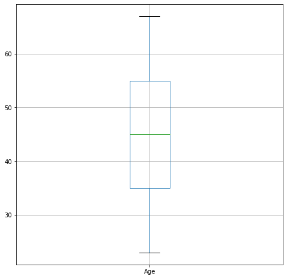

```python
# Check to see if there are any outliers
bank_df.boxplot(column="Age",return_type='axes',figsize=(8,8))
```

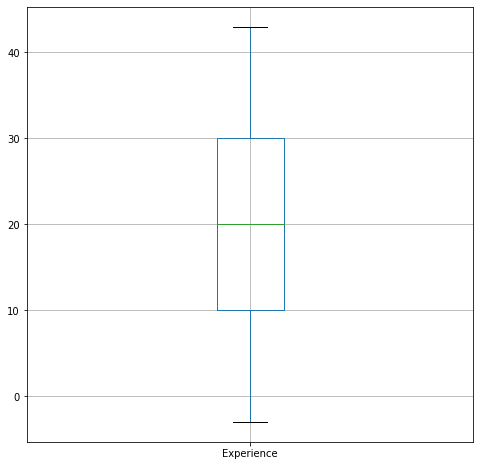

```python
# Experience has some negative values which are incorrect
bank_df.boxplot(column="Experience",return_type='axes',figsize=(8,8))
```

```python
# Remove ID as that is not needed for our analysis
bank_df = bank_df.drop(['ID'], axis=1)
```

```python
bank_df[bank_df.Experience < 0]
```

|  | Age | Experience | Income | ZIP Code | Family | CCAvg | Education | Mortgage | Personal Loan | Securities Account | CD Account | Online | CreditCard |
| --- | --- | --- | --- | --- | --- | --- | --- | --- | --- | --- | --- | --- | --- |
| 89 | 25 | -1 | 113 | 94303 | 4 | 2.30 | 3 | 0 | 0 | 0 | 0 | 0 | 1 |
| 226 | 24 | -1 | 39 | 94085 | 2 | 1.70 | 2 | 0 | 0 | 0 | 0 | 0 | 0 |
| 315 | 24 | -2 | 51 | 90630 | 3 | 0.30 | 3 | 0 | 0 | 0 | 0 | 1 | 0 |
| 451 | 28 | -2 | 48 | 94132 | 2 | 1.75 | 3 | 89 | 0 | 0 | 0 | 1 | 0 |
| 524 | 24 | -1 | 75 | 93014 | 4 | 0.20 | 1 | 0 | 0 | 0 | 0 | 1 | 0 |
| 536 | 25 | -1 | 43 | 92173 | 3 | 2.40 | 2 | 176 | 0 | 0 | 0 | 1 | 0 |
| 540 | 25 | -1 | 109 | 94010 | 4 | 2.30 | 3 | 314 | 0 | 0 | 0 | 1 | 0 |
| 576 | 25 | -1 | 48 | 92870 | 3 | 0.30 | 3 | 0 | 0 | 0 | 0 | 0 | 1 |
| 583 | 24 | -1 | 38 | 95045 | 2 | 1.70 | 2 | 0 | 0 | 0 | 0 | 1 | 0 |
| 597 | 24 | -2 | 125 | 92835 | 2 | 7.20 | 1 | 0 | 0 | 1 | 0 | 0 | 1 |
| 649 | 25 | -1 | 82 | 92677 | 4 | 2.10 | 3 | 0 | 0 | 0 | 0 | 1 | 0 |
| 670 | 23 | -1 | 61 | 92374 | 4 | 2.60 | 1 | 239 | 0 | 0 | 0 | 1 | 0 |
| 686 | 24 | -1 | 38 | 92612 | 4 | 0.60 | 2 | 0 | 0 | 0 | 0 | 1 | 0 |
| 793 | 24 | -2 | 150 | 94720 | 2 | 2.00 | 1 | 0 | 0 | 0 | 0 | 1 | 0 |
| 889 | 24 | -2 | 82 | 91103 | 2 | 1.60 | 3 | 0 | 0 | 0 | 0 | 1 | 1 |
| 909 | 23 | -1 | 149 | 91709 | 1 | 6.33 | 1 | 305 | 0 | 0 | 0 | 0 | 1 |
| 1173 | 24 | -1 | 35 | 94305 | 2 | 1.70 | 2 | 0 | 0 | 0 | 0 | 0 | 0 |
| 1428 | 25 | -1 | 21 | 94583 | 4 | 0.40 | 1 | 90 | 0 | 0 | 0 | 1 | 0 |
| 1522 | 25 | -1 | 101 | 94720 | 4 | 2.30 | 3 | 256 | 0 | 0 | 0 | 0 | 1 |
| 1905 | 25 | -1 | 112 | 92507 | 2 | 2.00 | 1 | 241 | 0 | 0 | 0 | 1 | 0 |
| 2102 | 25 | -1 | 81 | 92647 | 2 | 1.60 | 3 | 0 | 0 | 0 | 0 | 1 | 1 |
| 2430 | 23 | -1 | 73 | 92120 | 4 | 2.60 | 1 | 0 | 0 | 0 | 0 | 1 | 0 |
| 2466 | 24 | -2 | 80 | 94105 | 2 | 1.60 | 3 | 0 | 0 | 0 | 0 | 1 | 0 |
| 2545 | 25 | -1 | 39 | 94720 | 3 | 2.40 | 2 | 0 | 0 | 0 | 0 | 1 | 0 |
| 2618 | 23 | -3 | 55 | 92704 | 3 | 2.40 | 2 | 145 | 0 | 0 | 0 | 1 | 0 |
| 2717 | 23 | -2 | 45 | 95422 | 4 | 0.60 | 2 | 0 | 0 | 0 | 0 | 1 | 1 |
| 2848 | 24 | -1 | 78 | 94720 | 2 | 1.80 | 2 | 0 | 0 | 0 | 0 | 0 | 0 |
| 2876 | 24 | -2 | 80 | 91107 | 2 | 1.60 | 3 | 238 | 0 | 0 | 0 | 0 | 0 |
| 2962 | 23 | -2 | 81 | 91711 | 2 | 1.80 | 2 | 0 | 0 | 0 | 0 | 0 | 0 |
| 2980 | 25 | -1 | 53 | 94305 | 3 | 2.40 | 2 | 0 | 0 | 0 | 0 | 0 | 0 |
| 3076 | 29 | -1 | 62 | 92672 | 2 | 1.75 | 3 | 0 | 0 | 0 | 0 | 0 | 1 |
| 3130 | 23 | -2 | 82 | 92152 | 2 | 1.80 | 2 | 0 | 0 | 1 | 0 | 0 | 1 |
| 3157 | 23 | -1 | 13 | 94720 | 4 | 1.00 | 1 | 84 | 0 | 0 | 0 | 1 | 0 |
| 3279 | 26 | -1 | 44 | 94901 | 1 | 2.00 | 2 | 0 | 0 | 0 | 0 | 0 | 0 |
| 3284 | 25 | -1 | 101 | 95819 | 4 | 2.10 | 3 | 0 | 0 | 0 | 0 | 0 | 1 |
| 3292 | 25 | -1 | 13 | 95616 | 4 | 0.40 | 1 | 0 | 0 | 1 | 0 | 0 | 0 |
| 3394 | 25 | -1 | 113 | 90089 | 4 | 2.10 | 3 | 0 | 0 | 0 | 0 | 1 | 0 |
| 3425 | 23 | -1 | 12 | 91605 | 4 | 1.00 | 1 | 90 | 0 | 0 | 0 | 1 | 0 |
| 3626 | 24 | -3 | 28 | 90089 | 4 | 1.00 | 3 | 0 | 0 | 0 | 0 | 0 | 0 |
| 3796 | 24 | -2 | 50 | 94920 | 3 | 2.40 | 2 | 0 | 0 | 1 | 0 | 0 | 0 |
| 3824 | 23 | -1 | 12 | 95064 | 4 | 1.00 | 1 | 0 | 0 | 1 | 0 | 0 | 1 |
| 3887 | 24 | -2 | 118 | 92634 | 2 | 7.20 | 1 | 0 | 0 | 1 | 0 | 1 | 0 |
| 3946 | 25 | -1 | 40 | 93117 | 3 | 2.40 | 2 | 0 | 0 | 0 | 0 | 1 | 0 |
| 4015 | 25 | -1 | 139 | 93106 | 2 | 2.00 | 1 | 0 | 0 | 0 | 0 | 0 | 1 |
| 4088 | 29 | -1 | 71 | 94801 | 2 | 1.75 | 3 | 0 | 0 | 0 | 0 | 0 | 0 |
| 4116 | 24 | -2 | 135 | 90065 | 2 | 7.20 | 1 | 0 | 0 | 0 | 0 | 1 | 0 |
| 4285 | 23 | -3 | 149 | 93555 | 2 | 7.20 | 1 | 0 | 0 | 0 | 0 | 1 | 0 |
| 4411 | 23 | -2 | 75 | 90291 | 2 | 1.80 | 2 | 0 | 0 | 0 | 0 | 1 | 1 |
| 4481 | 25 | -2 | 35 | 95045 | 4 | 1.00 | 3 | 0 | 0 | 0 | 0 | 1 | 0 |
| 4514 | 24 | -3 | 41 | 91768 | 4 | 1.00 | 3 | 0 | 0 | 0 | 0 | 1 | 0 |
| 4582 | 25 | -1 | 69 | 92691 | 3 | 0.30 | 3 | 0 | 0 | 0 | 0 | 1 | 0 |
| 4957 | 29 | -1 | 50 | 95842 | 2 | 1.75 | 3 | 0 | 0 | 0 | 0 | 0 | 1 |

```python
# I guess Imputer is not a good idea here

#from sklearn.impute import SimpleImputer
#rep_0 = SimpleImputer(missing_values=0, strategy="mean")
#cols=['Experienc']
#imputer = rep_0.fit(pdata[cols])
#bank_df[cols] = imputer.transform(bank_df[cols])



#bank_df.head(10)
```

```python
bank_df.loc[bank_df.Experience < 0, 'Experience'] = 0
bank_df[bank_df.Experience < 0]
```

|  | Age | Experience | Income | ZIP Code | Family | CCAvg | Education | Mortgage | Personal Loan | Securities Account | CD Account | Online | CreditCard |
| --- | --- | --- | --- | --- | --- | --- | --- | --- | --- | --- | --- | --- | --- |

```python
# Now get the statistical details after some cleansing
# Get Statistical Details of the data
bank_df.describe()
```

|  | Age | Experience | Income | ZIP Code | Family | CCAvg | Education | Mortgage | Personal Loan | Securities Account | CD Account | Online | CreditCard |
| --- | --- | --- | --- | --- | --- | --- | --- | --- | --- | --- | --- | --- | --- |
| count | 5,000.00 | 5,000.00 | 5,000.00 | 5,000.00 | 5,000.00 | 5,000.00 | 5,000.00 | 5,000.00 | 5,000.00 | 5,000.00 | 5,000.00 | 5,000.00 | 5,000.00 |
| mean | 45.34 | 20.12 | 73.77 | 93,152.50 | 2.40 | 1.94 | 1.88 | 56.50 | 0.10 | 0.10 | 0.06 | 0.60 | 0.29 |
| std | 11.46 | 11.44 | 46.03 | 2,121.85 | 1.15 | 1.75 | 0.84 | 101.71 | 0.29 | 0.31 | 0.24 | 0.49 | 0.46 |
| min | 23.00 | 0.00 | 8.00 | 9,307.00 | 1.00 | 0.00 | 1.00 | 0.00 | 0.00 | 0.00 | 0.00 | 0.00 | 0.00 |
| 25% | 35.00 | 10.00 | 39.00 | 91,911.00 | 1.00 | 0.70 | 1.00 | 0.00 | 0.00 | 0.00 | 0.00 | 0.00 | 0.00 |
| 50% | 45.00 | 20.00 | 64.00 | 93,437.00 | 2.00 | 1.50 | 2.00 | 0.00 | 0.00 | 0.00 | 0.00 | 1.00 | 0.00 |
| 75% | 55.00 | 30.00 | 98.00 | 94,608.00 | 3.00 | 2.50 | 3.00 | 101.00 | 0.00 | 0.00 | 0.00 | 1.00 | 1.00 |
| max | 67.00 | 43.00 | 224.00 | 96,651.00 | 4.00 | 10.00 | 3.00 | 635.00 | 1.00 | 1.00 | 1.00 | 1.00 | 1.00 |

```python
bank_df.describe()
```

|  | Age | Experience | Income | ZIP Code | Family | CCAvg | Education | Mortgage | Personal Loan | Securities Account | CD Account | Online | CreditCard |
| --- | --- | --- | --- | --- | --- | --- | --- | --- | --- | --- | --- | --- | --- |
| count | 5,000.00 | 5,000.00 | 5,000.00 | 5,000.00 | 5,000.00 | 5,000.00 | 5,000.00 | 5,000.00 | 5,000.00 | 5,000.00 | 5,000.00 | 5,000.00 | 5,000.00 |
| mean | 45.34 | 20.12 | 73.77 | 93,152.50 | 2.40 | 1.94 | 1.88 | 56.50 | 0.10 | 0.10 | 0.06 | 0.60 | 0.29 |
| std | 11.46 | 11.44 | 46.03 | 2,121.85 | 1.15 | 1.75 | 0.84 | 101.71 | 0.29 | 0.31 | 0.24 | 0.49 | 0.46 |
| min | 23.00 | 0.00 | 8.00 | 9,307.00 | 1.00 | 0.00 | 1.00 | 0.00 | 0.00 | 0.00 | 0.00 | 0.00 | 0.00 |
| 25% | 35.00 | 10.00 | 39.00 | 91,911.00 | 1.00 | 0.70 | 1.00 | 0.00 | 0.00 | 0.00 | 0.00 | 0.00 | 0.00 |
| 50% | 45.00 | 20.00 | 64.00 | 93,437.00 | 2.00 | 1.50 | 2.00 | 0.00 | 0.00 | 0.00 | 0.00 | 1.00 | 0.00 |
| 75% | 55.00 | 30.00 | 98.00 | 94,608.00 | 3.00 | 2.50 | 3.00 | 101.00 | 0.00 | 0.00 | 0.00 | 1.00 | 1.00 |
| max | 67.00 | 43.00 | 224.00 | 96,651.00 | 4.00 | 10.00 | 3.00 | 635.00 | 1.00 | 1.00 | 1.00 | 1.00 | 1.00 |

```python
bank_df[bank_df.CCAvg == 0]
```

|  | Age | Experience | Income | ZIP Code | Family | CCAvg | Education | Mortgage | Personal Loan | Securities Account | CD Account | Online | CreditCard |
| --- | --- | --- | --- | --- | --- | --- | --- | --- | --- | --- | --- | --- | --- |
| 63 | 42 | 17 | 32 | 94523 | 4 | 0.00 | 2 | 0 | 0 | 0 | 0 | 1 | 0 |
| 128 | 38 | 14 | 74 | 92182 | 2 | 0.00 | 1 | 0 | 0 | 1 | 0 | 1 | 0 |
| 198 | 27 | 3 | 59 | 94123 | 4 | 0.00 | 1 | 90 | 0 | 1 | 0 | 1 | 0 |
| 210 | 51 | 26 | 20 | 92131 | 2 | 0.00 | 1 | 0 | 0 | 0 | 0 | 0 | 0 |
| 215 | 38 | 14 | 92 | 95818 | 2 | 0.00 | 1 | 249 | 0 | 0 | 0 | 1 | 1 |
| ... | ... | ... | ... | ... | ... | ... | ... | ... | ... | ... | ... | ... | ... |
| 4801 | 34 | 10 | 88 | 94404 | 2 | 0.00 | 1 | 121 | 0 | 0 | 0 | 1 | 0 |
| 4826 | 56 | 31 | 81 | 93943 | 2 | 0.00 | 3 | 225 | 0 | 0 | 0 | 0 | 0 |
| 4837 | 36 | 10 | 183 | 95348 | 2 | 0.00 | 1 | 0 | 0 | 0 | 0 | 0 | 0 |
| 4910 | 48 | 22 | 120 | 90291 | 1 | 0.00 | 1 | 0 | 0 | 0 | 0 | 1 | 0 |
| 4949 | 29 | 5 | 64 | 94114 | 4 | 0.00 | 1 | 249 | 0 | 0 | 0 | 0 | 1 |

106 rows × 13 columns

```python
sum(bank_df.duplicated())
```

```
0
```

```python
# Number of unique in each column
bank_df.nunique()
```

```
Age                    45
Experience             44
Income                162
ZIP Code              467
Family                  4
CCAvg                 108
Education               3
Mortgage              347
Personal Loan           2
Securities Account      2
CD Account              2
Online                  2
CreditCard              2
dtype: int64
```

```python
# Number of people with zero mortgage
bank_df[bank_df.Mortgage == 0].shape[0]
```

```
3462
```

```python
# Number of people with zero credit card spending per month
bank_df[bank_df.CCAvg == 0].shape[0]
```

```
106
```

```python
bank_df['Personal Loan'].value_counts()
```

```
0    4520
1     480
Name: Personal Loan, dtype: int64
```

```python
bank_df['Securities Account'].value_counts()
```

```
0    4478
1     522
Name: Securities Account, dtype: int64
```

```python
bank_df['CD Account'].value_counts()
```

```
0    4698
1     302
Name: CD Account, dtype: int64
```

```python
bank_df['Online'].value_counts()
```

```
1    2984
0    2016
Name: Online, dtype: int64
```

```python
bank_df['CCAvg'].value_counts()
```

```
0.30    241
1.00    231
0.20    204
2.00    188
0.80    187
       ...
2.75      1
8.20      1
9.30      1
3.67      1
5.33      1
Name: CCAvg, Length: 108, dtype: int64
```

```python
for i in list(bank_df.columns):   # checking value counts of all columns
    print(bank_df[i].value_counts())
    print()
```

```
35    151
43    149
52    145
58    143
54    143
50    138
41    136
30    136
56    135
34    134
39    133
59    132
57    132
51    129
60    127
```

[output cut: 160 more lines]

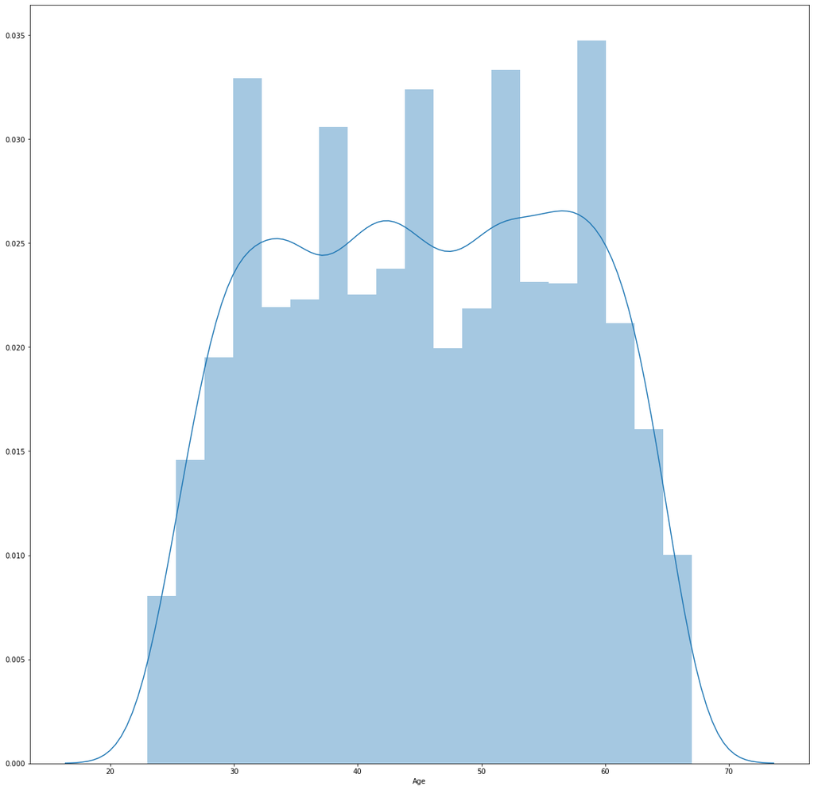

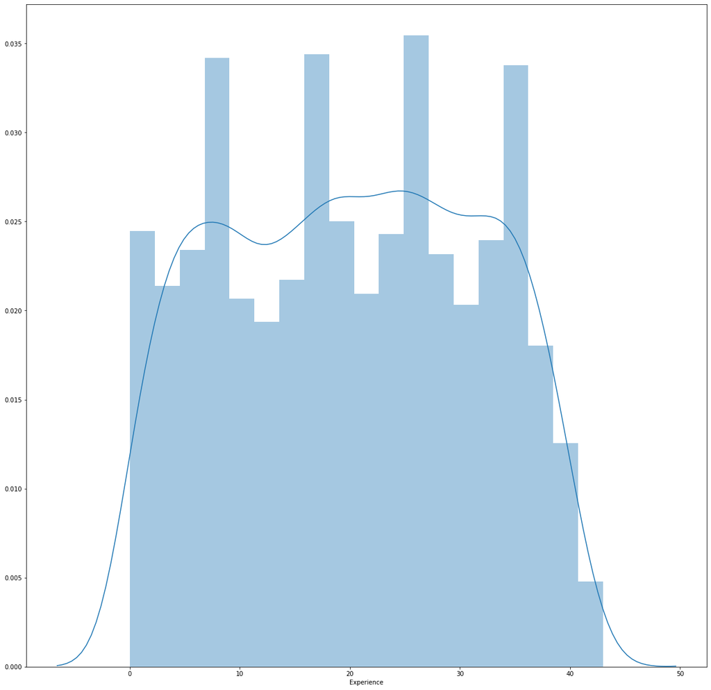

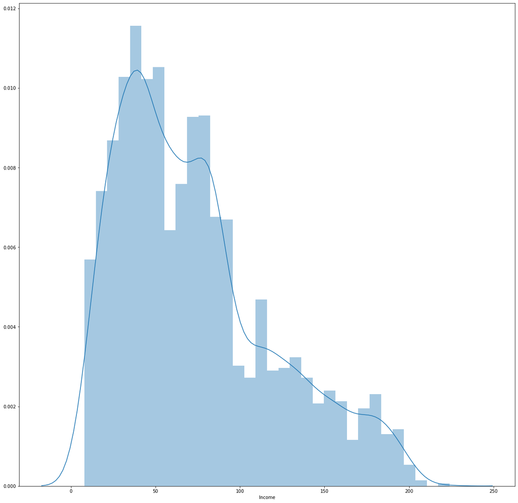

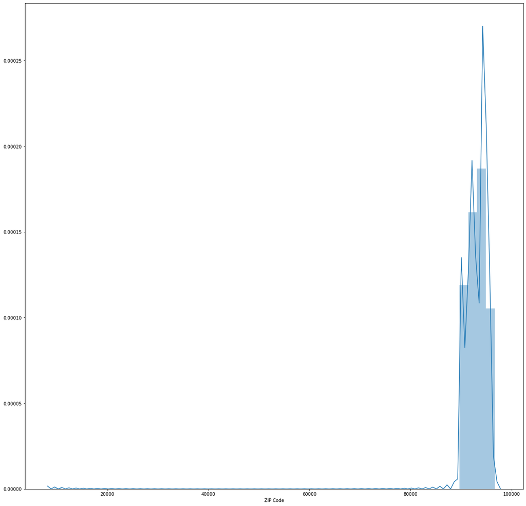

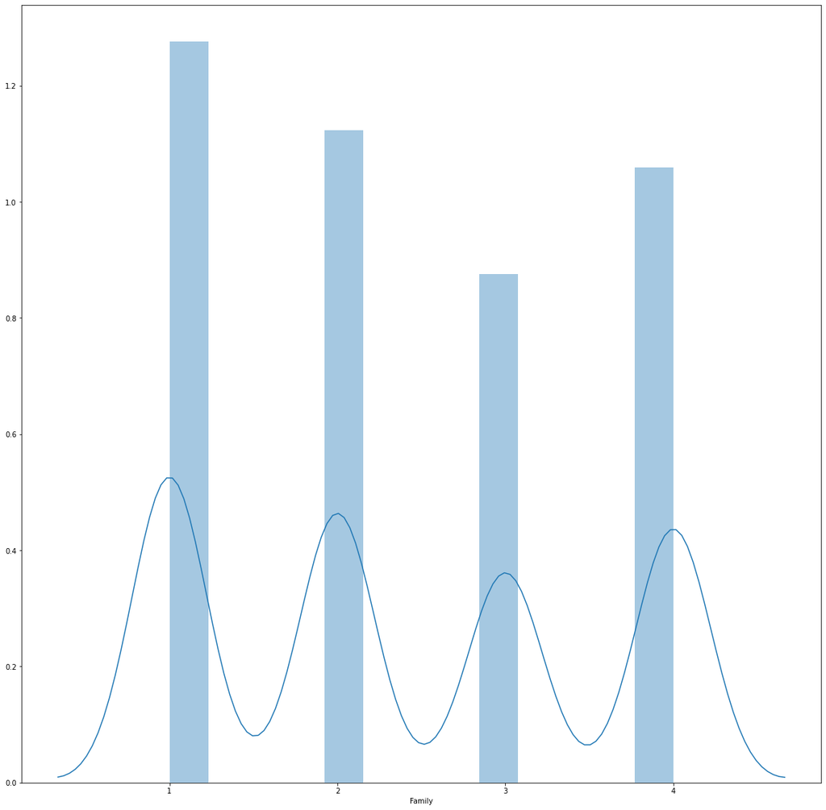

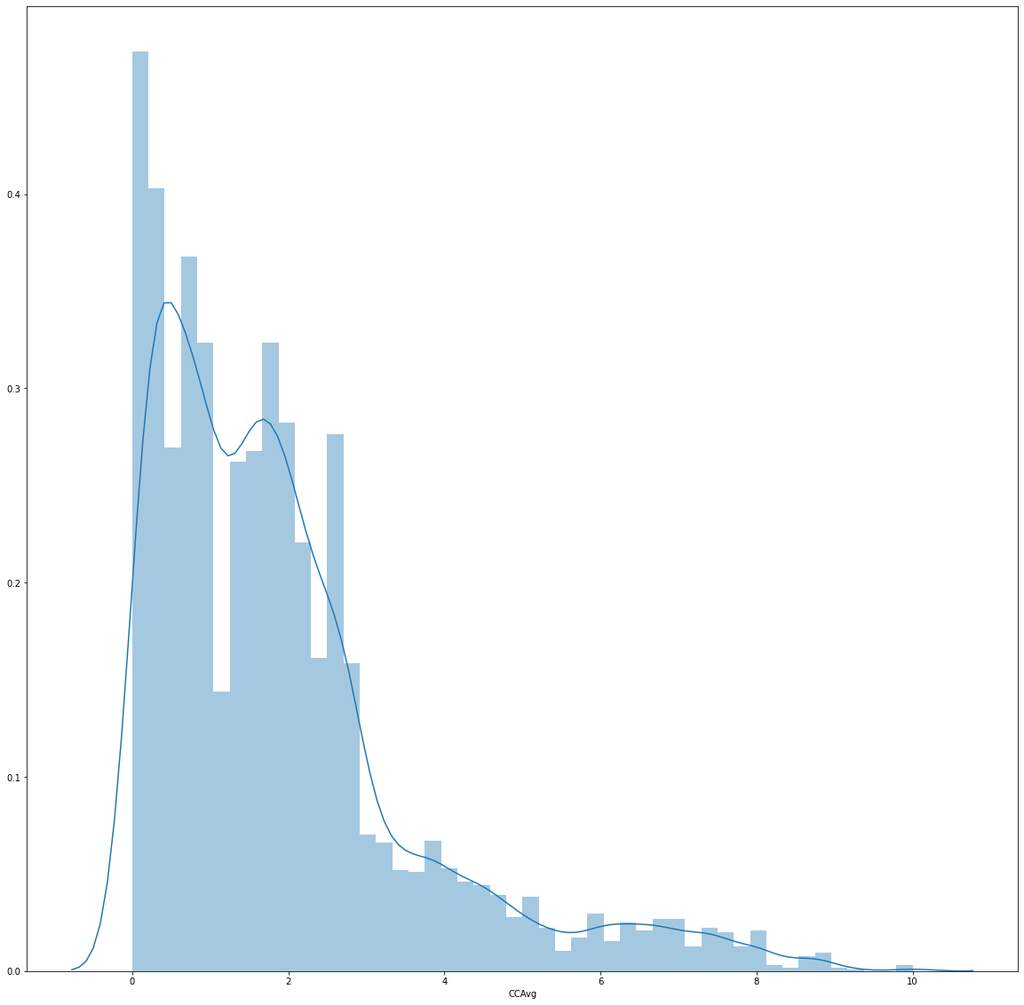

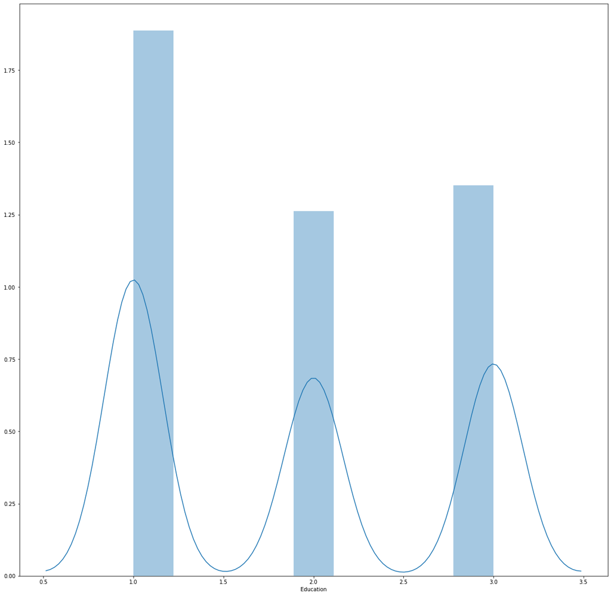

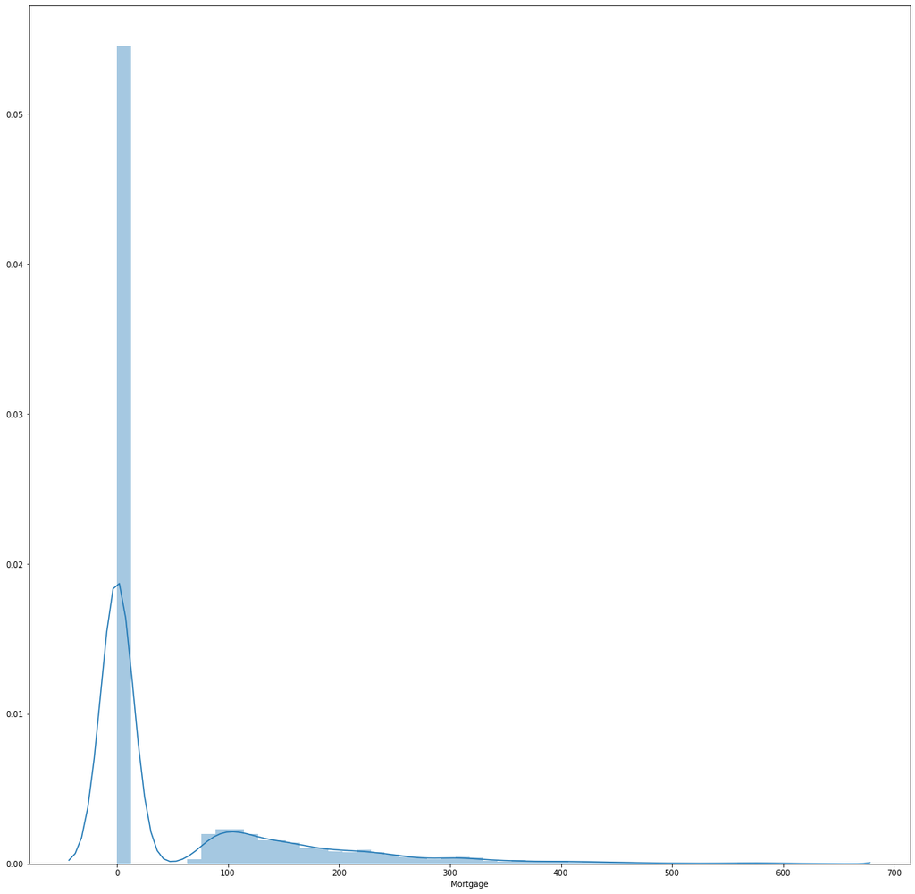

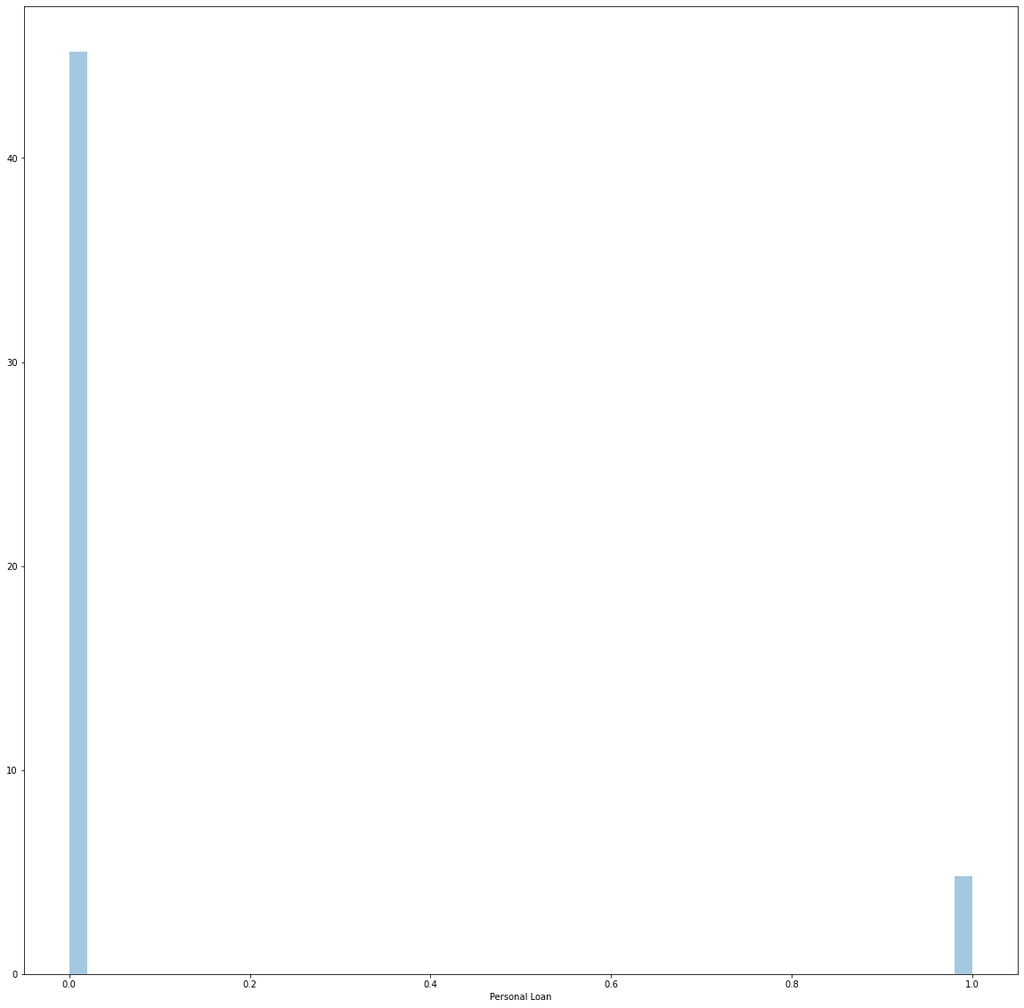

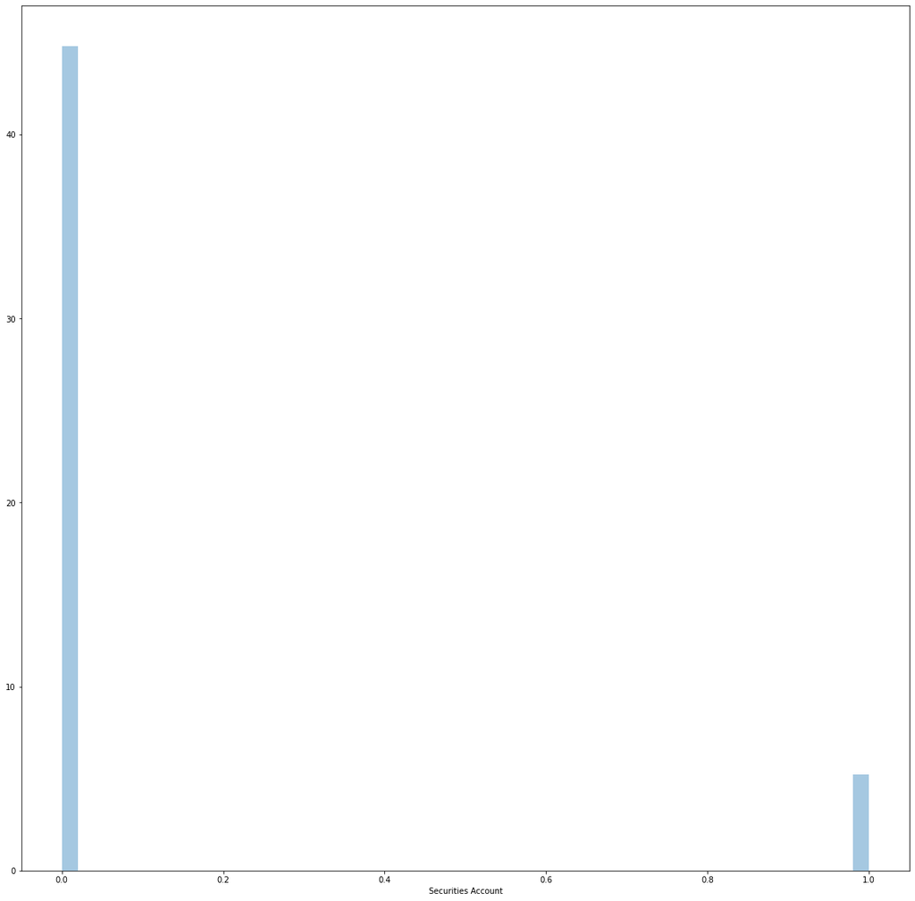

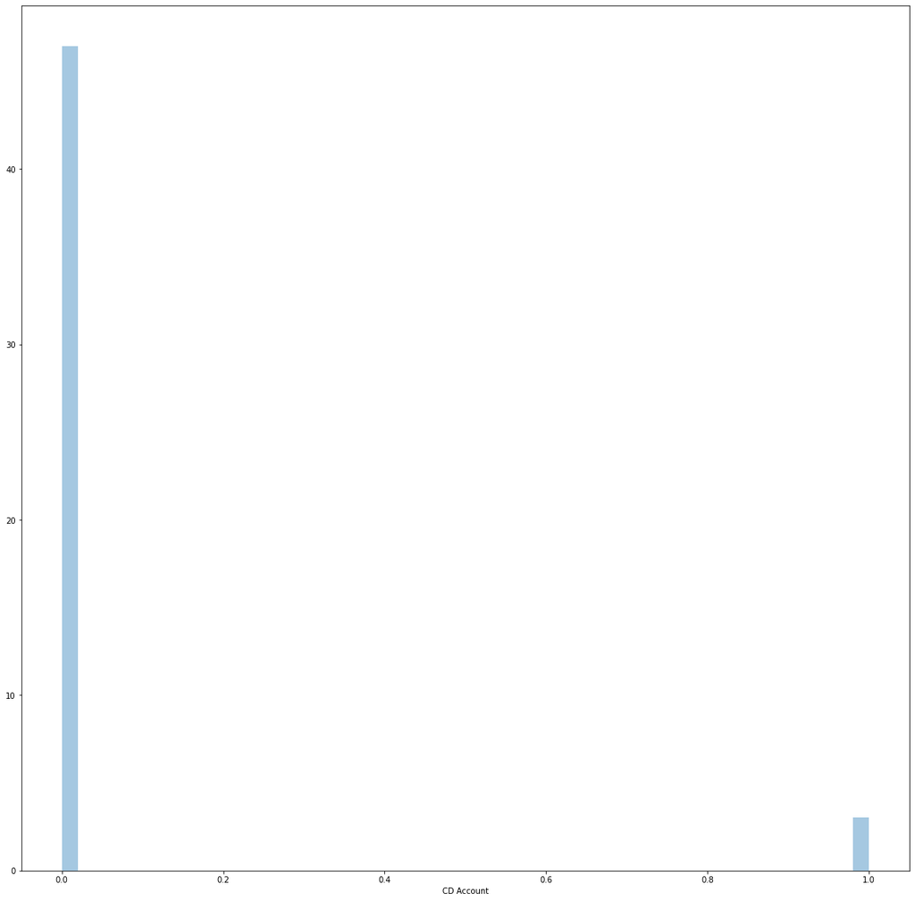

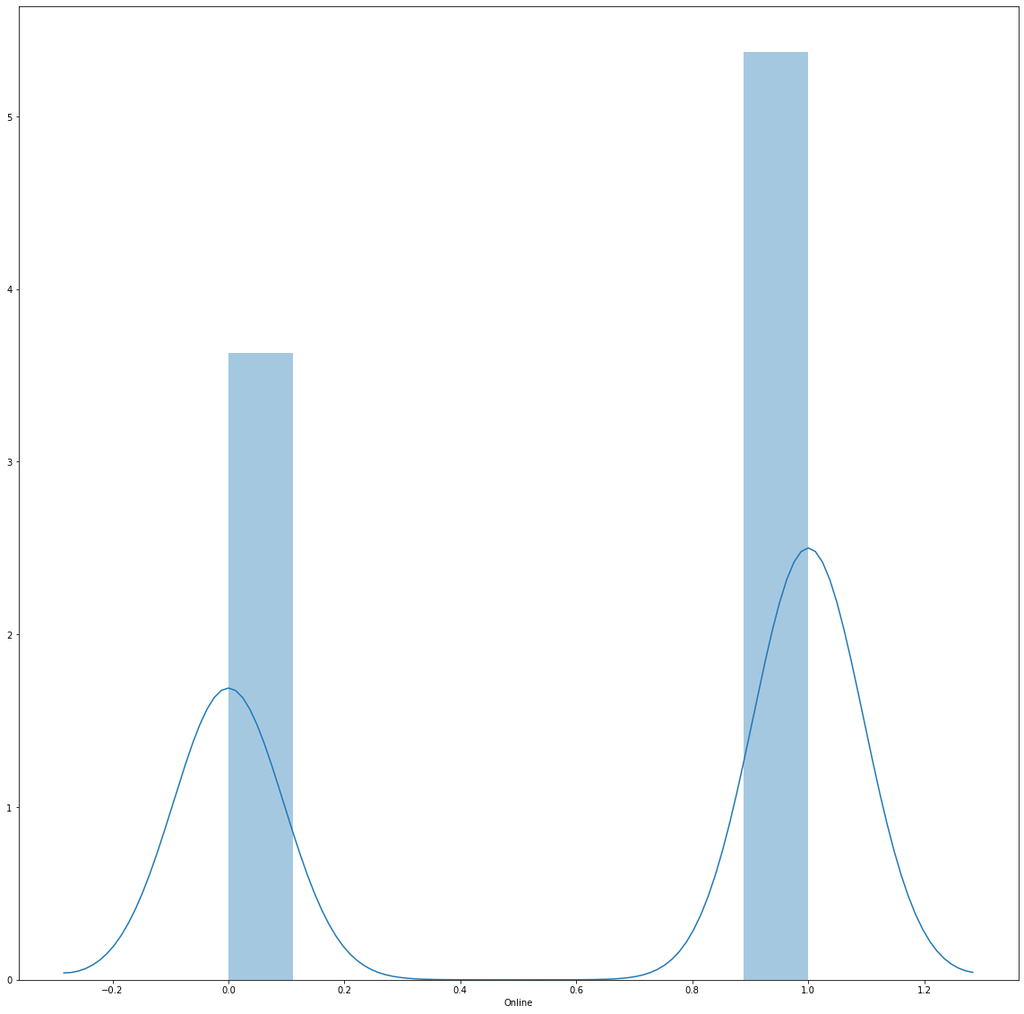

[1 more figures not shown]

```python
# let us plot all the columns to look at their distributions

for i in bank_df.columns:
    plt.figure(figsize = (20,20))
    sns.distplot(bank_df[i])
    plt.show()
```

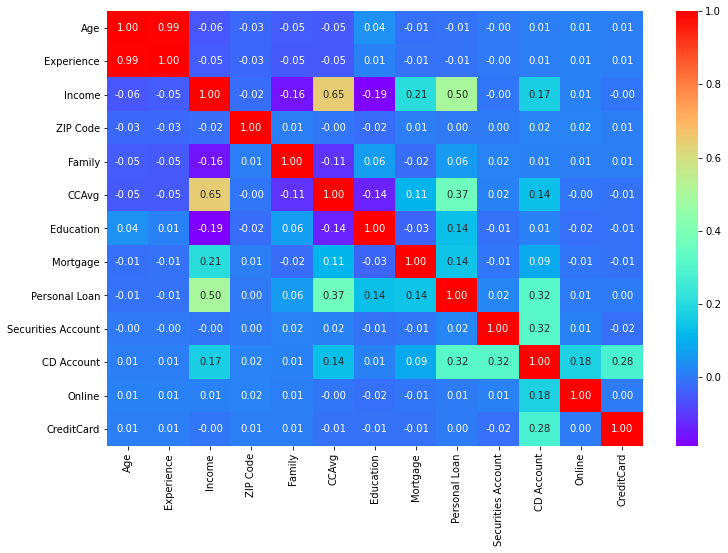

```python
plt.figure(figsize=(12,8))
sns.heatmap(bank_df.corr(),annot=True,fmt='.2f',cmap='rainbow', )
plt.show()
```

**Insights:**

- `Personal Loan has correlation with Income,CCAvg,CD Account,Education and Mortgage`
- `Based on the above observation we can remove the other columns`

```python
# Remove ID as that is not needed for our analysis
bank_df = bank_df.drop(['Age','Experience','ZIP Code','Family','Securities Account', 'Online','CreditCard'], axis=1)
```

```python
bank_df.head()
```

|  | Income | CCAvg | Education | Mortgage | Personal Loan | CD Account |
| --- | --- | --- | --- | --- | --- | --- |
| 0 | 49 | 1.60 | 1 | 0 | 0 | 0 |
| 1 | 34 | 1.50 | 1 | 0 | 0 | 0 |
| 2 | 11 | 1.00 | 1 | 0 | 0 | 0 |
| 3 | 100 | 2.70 | 2 | 0 | 0 | 0 |
| 4 | 45 | 1.00 | 2 | 0 | 0 | 0 |

```python
Y = bank_df['Personal Loan']
X = bank_df.drop(columns = {'Personal Loan'})
```

```python
#splitting the data in 70:30 ratio of train to test data
X_train, X_test, y_train, y_test = train_test_split(X, Y, test_size=0.30 , random_state=1)
```

```python
#intialise the model to be fit and fir the model on the train data
regression_model = LinearRegression(fit_intercept=True)
regression_model.fit(X_train, y_train)
```

```
LinearRegression()
```

```python
#get the R-square score the fitted train data

print('The coefficient of determination R^2 of the prediction on Train set', regression_model.score(X_train, y_train))
```

```
The coefficient of determination R^2 of the prediction on Train set 0.3653585748709127
```

```python
# write your own R-square function for the testing data

def r_squared(model, X, y):
    y_mean = y_train.mean()
    SST = ((y_train - y_mean)**2).sum()
    SSE = ((y_train - regression_model.predict(X_train))**2).sum()
    r_square = 1 - SSE/SST
    return SSE, SST, r_square

SSE, SST, r_square = r_squared(regression_model, X_train, y_train)
print("SSE: ", SSE)
print("SST: ", SST)
print("r_square: ", r_square)
```

```
SSE:  190.20004052385136
SST:  299.6968571428572
r_square:  0.3653585748709127
```

```python
print('The coefficient of determination R^2 of the prediction on Test set',regression_model.score(X_test, y_test))
```

```
The coefficient of determination R^2 of the prediction on Test set 0.3492316300642848
```

```python
print("The Root Mean Square Error (RMSE) of the model is for testing set is",np.sqrt(mean_squared_error(y_test,regression_model.predict(X_test))))
```

```
The Root Mean Square Error (RMSE) of the model is for testing set is 0.24129191366446995
```

```python
a = regression_model.coef_
coeff_data = pd.DataFrame()
coeff_data['Coefs'] = regression_model.coef_
coeff_data['Feature'] = X_train.columns
coeff_data = coeff_data.append({'Coefs': regression_model.intercept_, 'Feature': "Intercept"}, ignore_index = True)
coeff_data
```

|  | Coefs | Feature |
| --- | --- | --- |
| 0 | 0.00 | Income |
| 1 | 0.02 | CCAvg |
| 2 | 0.08 | Education |
| 3 | 0.00 | Mortgage |
| 4 | 0.27 | CD Account |
| 5 | -0.31 | Intercept |

## Logistic Regression

```python
#separating dependent and independent variables
A = bank_df.drop('Personal Loan',axis=1)
B = bank_df['Personal Loan']
```

```python
A
```

|  | Income | CCAvg | Education | Mortgage | CD Account |
| --- | --- | --- | --- | --- | --- |
| 0 | 49 | 1.60 | 1 | 0 | 0 |
| 1 | 34 | 1.50 | 1 | 0 | 0 |
| 2 | 11 | 1.00 | 1 | 0 | 0 |
| 3 | 100 | 2.70 | 2 | 0 | 0 |
| 4 | 45 | 1.00 | 2 | 0 | 0 |
| ... | ... | ... | ... | ... | ... |
| 4995 | 40 | 1.90 | 3 | 0 | 0 |
| 4996 | 15 | 0.40 | 1 | 85 | 0 |
| 4997 | 24 | 0.30 | 3 | 0 | 0 |
| 4998 | 49 | 0.50 | 2 | 0 | 0 |
| 4999 | 83 | 0.80 | 1 | 0 | 0 |

5000 rows × 5 columns

```python
B
```

```
0       0
1       0
2       0
3       0
4       0
       ..
4995    0
4996    0
4997    0
4998    0
4999    0
Name: Personal Loan, Length: 5000, dtype: int64
```

```python
from sklearn.model_selection import train_test_split

A_train, A_test, B_train, B_test = train_test_split( A, B, test_size = 0.3, random_state = 42 )
```

```python
from sklearn.linear_model import LogisticRegression

lr = LogisticRegression(random_state=7)
lr.fit(A_train,B_train)
```

```
LogisticRegression(random_state=7)
```

```python
B_predicted =  lr.predict(A_test)
B_predicted
```

```
array([0, 0, 0, ..., 0, 0, 1])
```

## Calculating Probabilities of Target using Sklearn

```python
C = pd.DataFrame()                                               # creating a new dataframe
C['Actual'] = B_test.values                                      # Storing actual output of target variable

C['Probaility that output is 0'] = lr.predict_proba(A_test)[:,0]
# Probabilities predicted by Logistic regression model
C['Probaility that output is 1'] = lr.predict_proba(A_test)[:,1]

C['Predicted'] = lr.predict(A_test)                               # Predicting target variable using sklearn Logistic regression

C.head()

# In sklearn default threshold is 0.5
# therfore for all the values whose probability for 1 is greater than 0.5 will be predicted as 1
```

|  | Actual | Probaility that output is 0 | Probaility that output is 1 | Predicted |
| --- | --- | --- | --- | --- |
| 0 | 0 | 1.00 | 0.00 | 0 |
| 1 | 1 | 0.87 | 0.13 | 0 |
| 2 | 0 | 0.96 | 0.04 | 0 |
| 3 | 0 | 1.00 | 0.00 | 0 |
| 4 | 0 | 1.00 | 0.00 | 0 |

## Build a Confusion Matrix

```python
from sklearn.metrics import confusion_matrix,accuracy_score
```

```python
def draw_cm( actual, predicted ):
    cm = confusion_matrix( actual, predicted, [1,0] )
    sns.heatmap(cm, annot=True,  fmt='.2f', xticklabels = ["Personal Loan", "No Personal Loan"] , yticklabels = ["Personal Loan", "No Personal Loan"] )
    plt.ylabel('True label')
    plt.xlabel('Predicted label')
    plt.show()
```

```python
C
```

|  | Actual | Probaility that output is 0 | Probaility that output is 1 | Predicted |
| --- | --- | --- | --- | --- |
| 0 | 0 | 1.00 | 0.00 | 0 |
| 1 | 1 | 0.87 | 0.13 | 0 |
| 2 | 0 | 0.96 | 0.04 | 0 |
| 3 | 0 | 1.00 | 0.00 | 0 |
| 4 | 0 | 1.00 | 0.00 | 0 |
| ... | ... | ... | ... | ... |
| 1495 | 1 | 0.39 | 0.61 | 1 |
| 1496 | 0 | 0.99 | 0.01 | 0 |
| 1497 | 0 | 0.99 | 0.01 | 0 |
| 1498 | 0 | 0.98 | 0.02 | 0 |
| 1499 | 1 | 0.02 | 0.98 | 1 |

1500 rows × 4 columns

## Heatmap to display confusion matrix

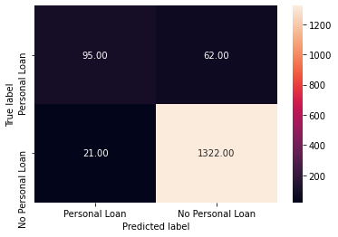

```python
draw_cm( C['Actual'], C['Predicted'] )
```

```python
print( 'Total Accuracy : ',np.round( accuracy_score( B_test, lr.predict(A_test) ), 2 ) )
```

```
Total Accuracy :  0.94
```

## Predicted Probability distribution Plots for defaulters and non defaulters

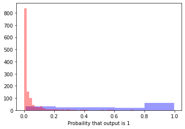

```python
sns.distplot( C[C['Actual'] == 1]["Probaility that output is 1"], kde=False, color = 'b' )
sns.distplot( C[C['Actual'] == 0]["Probaility that output is 1"], kde=False, color = 'r' )
plt.show()
```